# I AM THE DISCRIMINANT

~

2019-08-02

For over a year (intermittently, not cumulatively) i’ve been developing an R package, ordr, for incorporating ordination techniques into a tidyverse workflow. (Credit where it’s due: Emily Paul, a summer intern from Avon High School, helped extend the package functionality and has since used it in other projects and provided critical feedback on its design.) This week, i finally deployed [a pkgdown website](https://corybrunson.github.io/ordr/) and tweeted a meek solicitation for feedback.[^1] Interestingly, the one component that held me back, that i put off time and time again before finally grinding out a solution over the past few weeks, was the component that originally complemented PCA in [Vince Vu’s original and inspirational ggbiplot package](https://github.com/vqv/ggbiplot): Accessor methods for the MASS package implementation of linear discriminant analysis.

A big part of the reason for this procrastination was that [the source code of `MASS::lda()`](https://github.com/cran/MASS/blob/master/R/lda.R) looks nothing like the tidy definition of LDA found in textbooks. (I have on my shelf my mom’s copies of [Tatsuoka’s *Multivariate Analysis*](https://books.google.com/books/about/Multivariate_Analysis.html?id=HHNnBDaNsuUC) and of [Nunnally’s *Psychometric Theory*](https://books.google.com/books/about/Psychometric_theory.html?id=WE59AAAAMAAJ), but there are several similar introductions online, for example [Raschka’s](https://sebastianraschka.com/Articles/2014_python_lda.html).) In the standard presentation, LDA boils down to an eigendecomposition of the quotient ${C_W}^{-1}C_B$ of the between- by the within-group covariance matrices. (This is equivalent, up to a scale factor, to the eigendecomposition of the same quotient of the corresponding scatter matrices $S_\bullet=nC_\bullet$.[^2]) But rather than build up to a single eigendecomposition, `MASS::lda()` relies on sequential compositions of a scaling matrix with eigenvector and other matrices that are difficult to follow by reading the (minimally documented) code.

Meanwhile, several discussions of LDA on StackOverflow provide useful insights into the output of `MASS::lda()`, but the more prolific respondents tend not to use R, and the numerical examples derive from implementations in other languages. The MASS book, *Modern Applied Statistics with S* by Venables and Ripley ([PDF](https://tinyurl.com/yyhpyu2d)), details their mathematical formula in section 12.1 but does not discuss their implementation. So, while it’s still fresh in my mind, i want to offer what i hope will be an evergreen dissection of `MASS::lda()`. In a future post i’ll survey different ways an LDA might be summarized in a biplot and how i tweaked Venables and Ripley’s function to make these options available in ordr.

### tl;dr

`MASS::lda()` gradually and conditionally composes a variable transformation (a matrix that acts on the columns of the data matrix) to simplify the covariance quotient, then uses singular value decomposition to obtain its eigendecomposition. Rather than returning both the variable transformation and the quotient eigendecomposition, it returns their product, a matrix of discriminant coefficients that transforms the data and/or group centroids to their discriminant coordinates (scores). Consequently, the variable loadings cannot be recovered from the output.

### class methods

For those (like me until recently) unfamiliar with [the S3 object system](http://adv-r.had.co.nz/S3.html), [the `MASS::lda()` source code](https://github.com/cran/MASS/blob/master/R/lda.R) may look strange. Essentially, and henceforth assuming the MASS package has been attached so that `MASS::` is unnecessary, the generic function `lda()` performs *method dispatch* by checking the class(es) of its primary input `x`, then sending `x` (and any other inputs) to one of several class-specific methods `lda.<class>()`, or else to `lda.default()`. These methods are not exported, so they aren’t visible to the user.[^3] In the case of `lda()` every class-specific method transforms its input to a standard form (a data table `x` and a vector of group assignments `grouping`, plus any of several other parameters) and passes these to `lda.default()`. This default method is the workhorse of the implementation, so it’s the only chunk of source code i’ll get into here.

### example inputs and parameter settings

The code will be executed in sequence, punctuated by printouts and plots of key objects defined along the way. This requires assigning illustrative values to the function arguments. I’ll take as my example the famous diabetes data originally analyzed by [Reaven and Miller (1979)](https://link.springer.com/article/10.1007/BF00423145), available from [the heplots package](https://github.com/friendly/heplots), which consists of a BMI-type measure and the results of four glucose and insulin tests for 145 patients, along with their diagnostic grouping as non-diabetic (“normal”), subclinically (“chemical”) diabetic, and overtly diabetic.[^4] For our purposes, the only other required parameter is `tol`, the tolerance at which small values encountered along the matrix algebra are interpreted as zero.

```r
x <- heplots::Diabetes[, 1:5]
grouping <- heplots::Diabetes[, 6]
tol <- 1e-04
```

```r
set.seed(2)
s <- sort(sample(nrow(x), 6))
print(x[s, ])
```

```
##     relwt glufast glutest instest sspg
## 24   0.97      90     327     192  124
## 27   1.20      98     365     145  158
## 82   1.11      93     393     490  259
## 102  1.13      92     476     433  226
## 133  0.85     330    1520      13  303
## 134  0.81     123     557     130  152
```

```r
print(grouping[s])
```

```
## [1] Normal            Normal            Normal            Chemical_Diabetic
## [5] Overt_Diabetic    Overt_Diabetic
## Levels: Normal Chemical_Diabetic Overt_Diabetic
```

### data parameters and summary information

The first several lines of `lda.default()` capture summary information about the data table `x` (and ensure that it is a matrix) and the group assignments `grouping`: `n` is the number of cases in `x`, `p` is the number of variables, `g` is `grouping` coerced to a factor-valued vector, `lev` is the vector of factor levels (groups), `counts` is a vector of the number of cases assigned to each group, `proportions` is a vector of their proportions of `n`, and `ng` is the number of groups.

It will help to keep track of some mathematical notation for these concepts in parallel: Call the data matrix $X\in\mathbb{R}^{n\times p}$, the column vector of group assignments $g\in[q]^{n}$, and a diagonal matrix $N\in\mathbb{N}^{q\times q}$ of group counts $n_1,\ldots,n_q$. Note that `lev` and `ng` correspond to $[q]$ and $q$, respectively. Additionally let $G=(\delta_{g_i,k})\in\{0,1\}^{n\times q}$ denote the 0,1-matrix with $i,k$-th entry $1$ when case $i$ is assigned to group $k$. (I’ll use the indices $1\leq i\leq n$ for the cases, $1\leq j\leq p$ for the variables, and $1\leq k\leq q$ for the groups.)

```r
if(is.null(dim(x))) stop("'x' is not a matrix")
x <- as.matrix(x)
if(any(!is.finite(x)))
  stop("infinite, NA or NaN values in 'x'")
n <- nrow(x)
p <- ncol(x)
if(n != length(grouping))
  stop("nrow(x) and length(grouping) are different")
g <- as.factor(grouping)
lev <- lev1 <- levels(g)
counts <- as.vector(table(g))
# excised handling of `prior`
if(any(counts == 0L)) {
  empty <- lev[counts == 0L]
  warning(sprintf(ngettext(length(empty),
                           "group %s is empty",
                           "groups %s are empty"),
                  paste(empty, collapse = " ")), domain = NA)
  lev1 <- lev[counts > 0L]
  g <- factor(g, levels = lev1)
  counts <- as.vector(table(g))
}
proportions <- counts/n
ng <- length(proportions)
names(counts) <- lev1 # `names(prior)` excised
```

The steps are straightforward, with the exception of the handling of prior probabilities (`prior`), which is beyond our scope and which i’ve excised from the code. (When not provided, `prior` takes the default value `proportions`, which are explicitly defined within `lda.default()` and will be substituted for `prior` below.) If `grouping` is a factor that is missing elements of any of its levels, then these elements are removed from the analysis with a warning. I’ll also skip the lines relevant only to cross-validation (`CV = TRUE`), which include a compatibility check here and a large conditional chunk later on.

```r
# group counts and proportions of the total:
print(cbind(counts, proportions))
```

```
##                   counts proportions
## Normal                76   0.5241379
## Chemical_Diabetic     36   0.2482759
## Overt_Diabetic        33   0.2275862
```

### variable standardization and the correlation matrix

```r
## drop attributes to avoid e.g. matrix() methods
group.means <- tapply(c(x), list(rep(g, p), col(x)), mean)
f1 <- sqrt(diag(var(x - group.means[g,  ])))
if(any(f1 < tol)) {
  const <- format((1L:p)[f1 < tol])
  stop(sprintf(ngettext(length(const),
                        "variable %s appears to be constant within groups",
                        "variables %s appear to be constant within groups"),
               paste(const, collapse = " ")),
       domain = NA)
}
# scale columns to unit variance before checking for collinearity
scaling <- diag(1/f1, , p)
```

I’ll refer to ${X_0}$ as the “within-group centered data”. The group centroids are returned as the named member `means` of the ‘lda’-class object returned by `lda.default()`. The standard deviations of and correlations among (some of) the five variables are evident in their pairwise scatterplots, which here and forward fix the aspect ratio at 1:

```r
# group centroids
print(group.means)
```

```
##                           1         2         3        4        5
## Normal            0.9372368  91.18421  349.9737 172.6447 114.0000
## Chemical_Diabetic 1.0558333  99.30556  493.9444 288.0000 208.9722
## Overt_Diabetic    0.9839394 217.66667 1043.7576 106.0000 318.8788
```

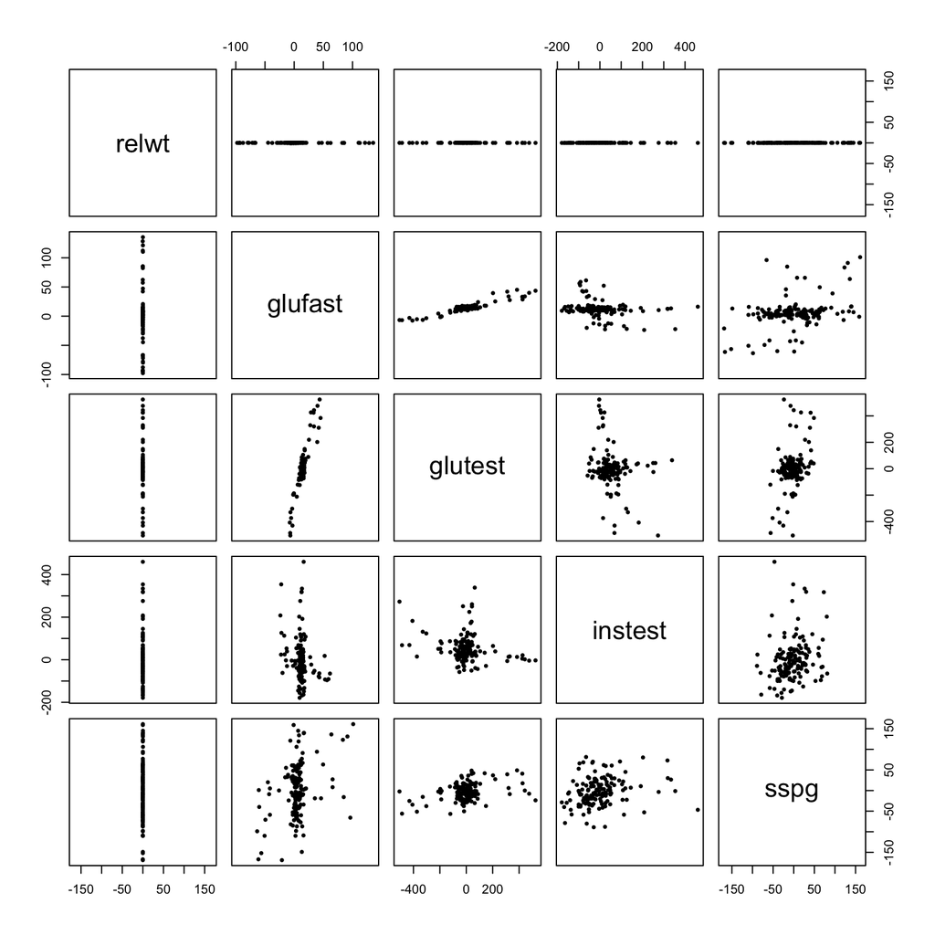

```r
# within-group centered data
pairs(x - group.means[g, ], asp = 1, pch = 19, cex = .5)
```

```r
# within-group standard deviations
print(f1)
```

```
##       relwt     glufast     glutest     instest        sspg
##   0.1195937  36.8753901 150.7536138 102.2913665  65.8125752
```

```r
# inverses of within-group standard deviations
scaling0 <- scaling
print(scaling0)
```

```
##          [,1]       [,2]       [,3]        [,4]       [,5]
## [1,] 8.361643 0.00000000 0.00000000 0.000000000 0.00000000
## [2,] 0.000000 0.02711836 0.00000000 0.000000000 0.00000000
## [3,] 0.000000 0.00000000 0.00663334 0.000000000 0.00000000
## [4,] 0.000000 0.00000000 0.00000000 0.009775996 0.00000000
## [5,] 0.000000 0.00000000 0.00000000 0.000000000 0.01519466
```

The object `scaling` will be redefined twice as the function proceeds, each time by multiplication on the right, concluding with the member named `scaling` of the ‘lda’ object. We’ll denote these redefinitions $S_1$ and $S_2$ and store the three definitions as `scaling0`, `scaling1`, and `scaling2` for unambiguous illustrations. These matrices act on the columns of ${X_0}$, which induces a two-sided action on $C_W$: $\frac{1}{n}({X_0}S)^\top({X_0}S)=S^\top C_WS$. The effect of $S_0$ is to standardize the variables, so that the covariance matrix of the transformed data ${X_0}S_0$ is the within-group correlation matrix $R_W$ of ${X_0}$. The effect is also evident from a comparison of the pairwise scatterplots:

```r
# within-group correlation matrix
print(cor(x - group.means[g, ]))
```

```
##               relwt     glufast    glutest    instest      sspg
## relwt    1.00000000 -0.09623213 -0.1607280  0.1070926 0.3926726
## glufast -0.09623213  1.00000000  0.9264021 -0.2513436 0.3692349
## glutest -0.16072796  0.92640213  1.0000000 -0.2494804 0.3633879
## instest  0.10709258 -0.25134359 -0.2494804  1.0000000 0.2145095
## sspg     0.39267262  0.36923495  0.3633879  0.2145095 1.0000000
```

```r
# within-group covariance matrix after standardization
print(cov((x - group.means[g, ]) %*% scaling))
```

```
##             [,1]        [,2]       [,3]       [,4]      [,5]
## [1,]  1.00000000 -0.09623213 -0.1607280  0.1070926 0.3926726
## [2,] -0.09623213  1.00000000  0.9264021 -0.2513436 0.3692349
## [3,] -0.16072796  0.92640213  1.0000000 -0.2494804 0.3633879
## [4,]  0.10709258 -0.25134359 -0.2494804  1.0000000 0.2145095
## [5,]  0.39267262  0.36923495  0.3633879  0.2145095 1.0000000
```

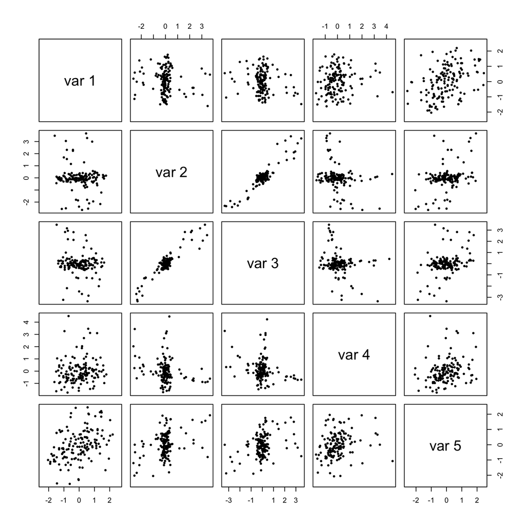

```r
# within-group centered data after standardization
pairs((x - group.means[g, ]) %*% scaling, asp = 1, pch = 19, cex = .5)
```

### variable sphering and the Mahalanobis distance

The next step in the procedure is the signature transformation of LDA. Whereas $S_0$ removes the scales of the variables, leaving them each with unit variance but preserving their correlations, the role of $S_1$ is to additionally remove these correlations. Viewing the set of cases within each group as a cloud of $n_k$ points in $\mathbb{R}^p$, $S_0$ stretches or compresses each cloud *along its coordinate axes*, while $S_1$ will stretch or compress it *along its principal components*. The resulting aggregate point cloud will have within-group covariance $I_n$ (the identity matrix), indicating unit variance and no correlation among its variables; according to these summary statistics, then, it is rotationally symmetric. Accordingly, the column action of $S_1$ is called a *sphering transformation*, while the distances among the transformed points are called their *Mahalanobis distances* after [their originator](https://en.wikipedia.org/wiki/Prasanta_Chandra_Mahalanobis). See [this SO answer by whuber](https://stats.stackexchange.com/a/62147/68743) for a helpful illustration of the transformation. Its importance is illustrated in Chapter 11 of [Greenacre’s *Biplots in Practice*](https://www.fbbva.es/microsite/multivariate-statistics/biplots.html) (p. 114).

$S_1$ is calculated differently for different choices of `method` (see the documentation `?MASS::lda`). For simplicity, the code chunk below follows the `"mle"` method. As hinted in the previous paragraph, the process of obtaining a sphering transformation is closely related to principal components analysis. One can be calculated via eigendecomposition of the standardized within-group covariance matrix or, equivalently, via singular value decomposition of the standardized within-group centered data $\hat{X}=X_0 S_0$.[^5] `lda.default()` performs SVD on $\hat{X}$, scaled by $\frac{1}{\sqrt{n}}$ so that the scatter matrix is $R_W$:

```r
fac <- 1/n # excise conditional case `method == "moment"`
X <- sqrt(fac) * (x - group.means[g,  ]) %*% scaling
X.s <- svd(X, nu = 0L)
rank <- sum(X.s$d > tol)
if(rank == 0L) stop("rank = 0: variables are numerically constant")
if(rank < p) warning("variables are collinear")
scaling <- scaling %*% X.s$v[, 1L:rank] %*% diag(1/X.s$d[1L:rank],,rank)
```

```r
# standardized within-group centered data
Xhat <- (x - group.means[g,  ]) %*% scaling0
# eigendecomposition of covariance
E <- eigen(cov(Xhat))
# sphering matrix (alternative calculation)
scaling0 %*% E$vectors %*% diag(1/sqrt(E$values))
```

```
##              [,1]          [,2]          [,3]         [,4]         [,5]
## [1,] -0.259027622  4.3010514864  5.4856218279 -6.620668927 -2.079154922
## [2,]  0.011804714 -0.0010406454 -0.0019199260 -0.013949375  0.070663381
## [3,]  0.002888749 -0.0004202234 -0.0008316344 -0.002406702 -0.017886747
## [4,] -0.001393182  0.0037523667 -0.0081405500 -0.005925590 -0.000197695
## [5,]  0.003470018  0.0076467225 -0.0008602899  0.018031665  0.001957544
```

```r
# sphering matrix
scaling1 <- scaling
print(scaling1)
```

```
##              [,1]         [,2]          [,3]         [,4]          [,5]
## [1,]  0.259925467  4.315959855 -5.5046361720 -6.643617588  2.0863617201
## [2,] -0.011845632 -0.001044253  0.0019265809 -0.013997727 -0.0709083156
## [3,] -0.002898762 -0.000421680  0.0008345171 -0.002415044  0.0179487460
## [4,]  0.001398012  0.003765373  0.0081687669 -0.005946129  0.0001983803
## [5,] -0.003482045  0.007673228  0.0008632718  0.018094166 -0.0019643291
```

The sphered within-group centered data now have identity within-group covariance matrix, up to a reasonable tolerance. The sphered coordinates are true to their name, as along each pair of variable coordinates the point cloud exhibits no elliptical tendencies. While `rank` is 5 ($=p$) at this stage, indicating that variation is detected in each of the variables, the final computational step will determine the rank of the LDA itself in terms of the transformed group centroids.

```r
# within-group covariance matrix after sphering
print(cov((x - group.means[g, ]) %*% scaling))
```

```
##               [,1]         [,2]          [,3]          [,4]          [,5]
## [1,]  1.006944e+00 3.762724e-16 -5.781689e-16  5.015188e-16  1.113855e-15
## [2,]  3.762724e-16 1.006944e+00  1.892763e-15  4.976970e-16  5.560143e-16
## [3,] -5.781689e-16 1.892763e-15  1.006944e+00 -9.853124e-16 -1.180559e-15
## [4,]  5.015188e-16 4.976970e-16 -9.853124e-16  1.006944e+00  1.095132e-15
## [5,]  1.113855e-15 5.560143e-16 -1.180559e-15  1.095132e-15  1.006944e+00
```

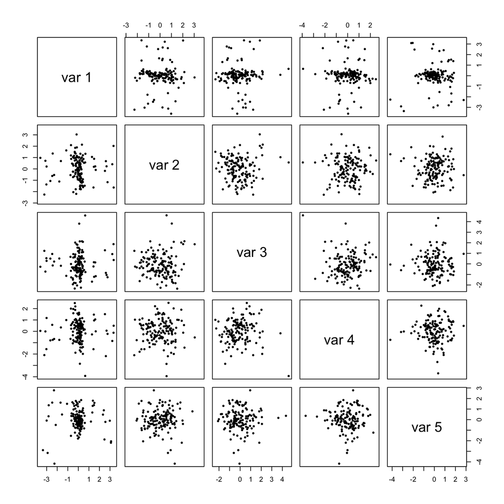

```r
# within-group centered data after sphering
pairs((x - group.means[g, ]) %*% scaling, asp = 1, pch = 19, cex = .5)
```

```r
# number of variables that contribute to the sphered data
print(rank)
```

```
## [1] 5
```

### sphering-transformed group centroids and discriminant coefficients

```r
xbar <- colSums(proportions %*% group.means) # sub `proportions` for `prior`
fac <- 1/(ng - 1) # excise conditional case `method == "mle"`
X <- sqrt((n * proportions)*fac) * # sub `proportions` for `prior`
  scale(group.means, center = xbar, scale = FALSE) %*% scaling
X.s <- svd(X, nu = 0L)
rank <- sum(X.s$d > tol * X.s$d[1L])
if(rank == 0L) stop("group means are numerically identical")
scaling <- scaling %*% X.s$v[, 1L:rank]
# excise conditional case `is.null(dimnames(x))`
dimnames(scaling) <- list(colnames(x), paste("LD", 1L:rank, sep = ""))
dimnames(group.means)[[2L]] <- colnames(x)
```

The rank now indicates the number of dimensions in the SVD of the sphering-transformed group centroids, which can be no more than $q-1$. The final reassignment of `scaling` gives $S_2$, the raw discriminant coefficients that express the discriminant coordinates of the centroids (and of the original data) as linear combinations of the centered variable coordinates. In practice, these discriminant coordinates are returned by the `predict()` method for ‘lda’ objects, `MASS:::predict.lda()`, and this is demonstrated to conclude the post:

```r
# number of dimensions in the sphering-transformed group centroid SVD
print(rank)
```

```
## [1] 2
```

```r
# discriminant coefficients
scaling2 <- scaling
print(scaling2)
```

```
##                   LD1          LD2
## relwt    1.3767523932 -3.823906854
## glufast -0.0340023755  0.037018266
## glutest  0.0127085491 -0.007166541
## instest -0.0001032987 -0.006238295
## sspg     0.0042877747  0.001145987
```

```r
# discriminant coordinates of centered group centroids
print((group.means - matrix(1, ng, 1) %*% t(xbar)) %*% scaling2)
```

```
##                          LD1        LD2
## Normal            -1.7683547  0.4043199
## Chemical_Diabetic  0.3437412 -1.3910995
## Overt_Diabetic     3.6975842  0.5864022
```

```r
# as recovered using `predict.lda()`
fit <- MASS::lda(group ~ ., heplots::Diabetes)
print(predict(fit, as.data.frame(fit$means))$x)
```

```
##                          LD1        LD2
## Normal            -1.7499658  0.4001154
## Chemical_Diabetic  0.3401666 -1.3766336
## Overt_Diabetic     3.6591334  0.5803043
```

(The slight discrepancy between the manually calculated coordinates and those returned by `predict()` is left as an exercise for the reader.)

[^1]: If you use ordination and ggplot2, not necessarily together (yet), i’d be grateful for your feedback, too!
[^2]: My exposition here assumes the covariances were calculated from a population rather than a sample perspective, but this introduces discrepancies in a few places.
[^3]: To see the source code for an object included in but not exported by a package, use three colons instead of two, e.g. `MASS:::lda.default`.
[^4]: I’ve been searching for a history of the 1970s change from categorizing diabetes as “clinical” versus “overt” to the present-day categories of “type 1” and “type 2”. Recommended reading is very welcome.
[^5]: These are equivalent because the matrix factors $U$ and $V$ of an SVD of any matrix $Z$ are the eigenvector matrices of $ZZ^\top$ and of $Z^\top Z$, respectively.
[^6]: These are not “sphered” centered group centroids because the sphering transformation is specific to the within-group centered data.